# test9.29

2023-09-29

**实验猜想**

- 在原假设pd=0的情况下，随机抽样得到一个估计的相位差假设为$\hat{pd}$，通过平移时序消除该相位差，会导致真实相位差$\hat{pd}$
- 在原假设pd=$\hat{pd}$的情况下，随机抽样得到一个估计的相位差假设为$\hat{pd}$，通过平移时序消除该相位差，会导致真实相位差为0
- 对比两种情况下相位差均值分布是否有较大差异
  - 若平移后的相位差与$\hat{pd}$的距离较小则说明真实相位差为0
  - 若平移后的相位差与$\hat{pd}$的距离较大说明真实相位差为$\hat{pd}$

### case1

**随机试验参数设置**

- 相位差：phasedif=0
- 周期：period=250
- 序列长度：length=2500

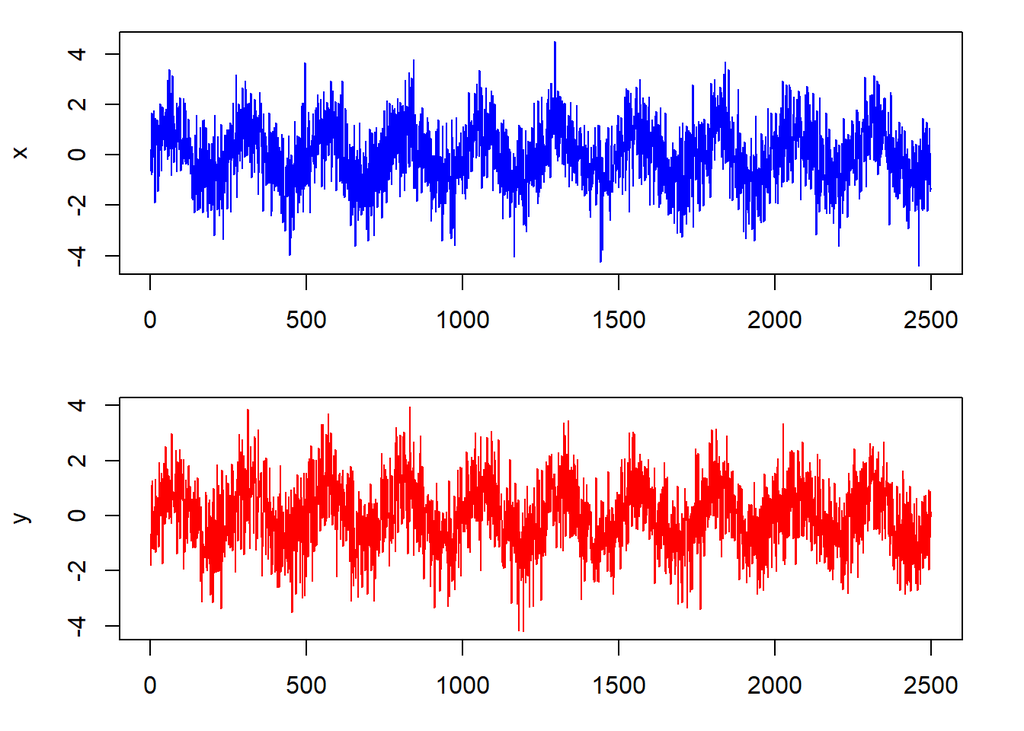

```r
set.seed(1)
cons_ts_pairs <- function(A,period,length,phasedif){
  #构造时间序列数据，参数：信噪比，周期，时序长度，相位差：X上的位移
  x <- A*periodic.series(start.period = period,length = length)+rnorm(length)
  y <- A*periodic.series(start.period = period,phase=phasedif,length = length)+rnorm(length)
  tsdf <- data.frame(x=x,y=y)
  return(invisible(tsdf))
}
tsdf <- cons_ts_pairs(1,250,2500,0)
par(mfrow = c(2,1),mar = c(3,4,1,2)+0.1)
plot(seq(1,dim(tsdf)[1]),tsdf$x,type ="l",col="blue",xlab="",ylab="x")
plot(seq(1,dim(tsdf)[1]),tsdf$y,type = "l",col="red",xlab="index",ylab="y")
```

### 1.1 原始相位差分布

- 计算随机抽取一组x-y时序对的相位差，画出相位差在各个时刻点的变化图
- 将相位差随时刻点变化的数据聚合成直方图，并标注相位差的均值

```r
tempwc <- analyze.coherency(tsdf,my.pair=c(1,2),
                              loess.span = 0,
                              dt=1,dj=1/50,
                              lowerPeriod=64,
                              upperPeriod=1024,
                              make.pval = T,
                              n.sim=10)
```

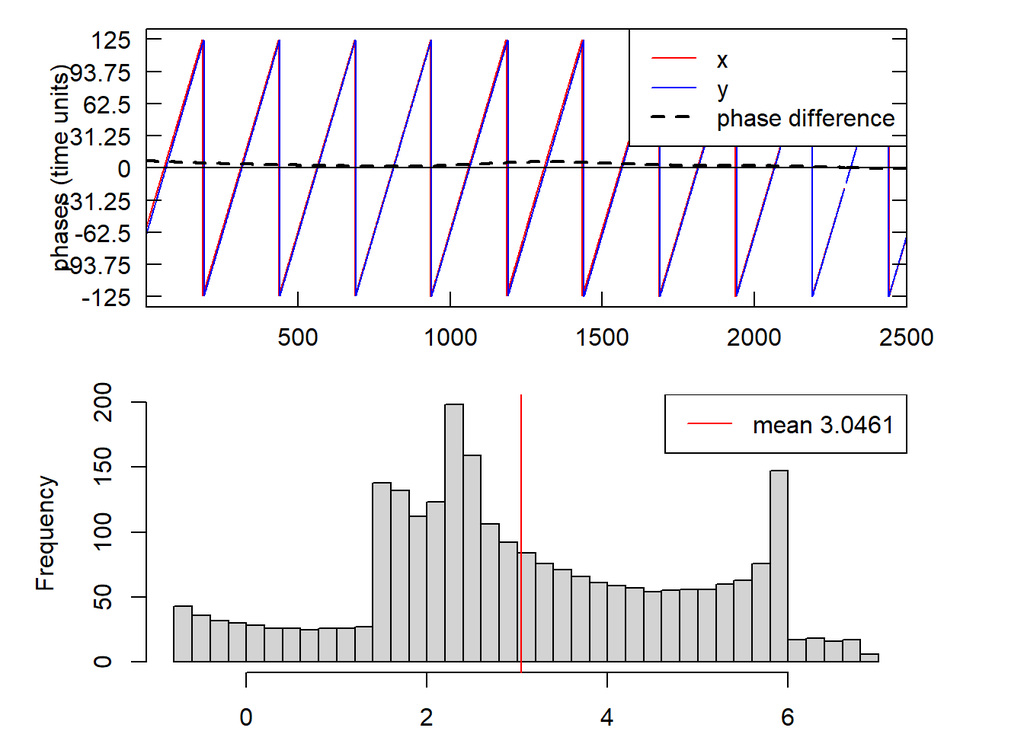

```r
#提取小波交叉谱计算相位角差值函数（相位差）
row.closest.to.period <- which.min(abs(tempwc$Period-250))
angle.series <- tempwc$Angle[row.closest.to.period,]#相位角差，范围在[-pi,pi]
phase <- (angle.series/pi)*(250/2)#相位差，范围在[-125,125]之间

#相位差图中坐标轴相位角到相位差的转换
at.ticks <- seq(from = -pi, to = pi, by = pi/4)
label.ticks <- (at.ticks/pi)*(250/2)

par(mfrow=c(2,1))
par(mar=c(2, 5, 1, 4))
wc.sel.phases(tempwc, sel.period = 250,
                only.sig = TRUE,
                which.sig = "wc",
                siglvl = 0.05,
                phaselim = c(-pi,+pi),
                phaselab = "phases (time units)",
                spec.phase.axis = list(at = at.ticks, labels = label.ticks),
                legend.coords = "topright", legend.horiz = FALSE,
                main = "", sub = "", timelab = "")
abline(h=0)
hist(phase,breaks=50,main="",xlab="length 2500")
abline(v=mean(phase),col="red")
legend("topright",paste("mean",round(mean(phase),4)),col="red",lty=1)
```

### 1.2修正相位差，分块重抽样分布

- 通过平移消除x,y的抽样相位差即`round(mean(phase))``
- 再对x进行分块重组500次
- 对每次重组后的x-y时序对计算相位差均值
- 画出相位差均值的直方图

```r
#block_bootstrap函数
bphase <- function(times,x,y){
  #传入参数:循环次数,需要计算小波相位角差值的两个时间序列
  cl <- makeCluster(detectCores())#设置并行环境
  registerDoParallel(cl)#设置为使用所有可用处理器核心
  #创建任务
  result <- foreach(i = 1:times,.combine='cbind') %dopar% {
    library(WaveletComp)
    sequence <- 1:length(x)
    # 将序列按照长度250为标准进行分块
    blocks <- matrix(sequence, nrow = 250)
    # 执行任务
    # 对分块进行随机重组产生新的排列顺序
    new_blocks <- c(blocks[, sample(ncol(blocks))])
    x_train <- x[new_blocks]
    tempwc <- analyze.coherency(data.frame(x=x_train,y=y),my.pair = c("x","y"),
                            loess.span = 0,
                            dt=1,dj=1/50,
                            lowerPeriod = 24,
                            upperPeriod = 1024,
                            make.pval = T,
                            n.sim=10)
    #计算两时序在周期为250附近的小波相位角差值
    temp_angle<- tempwc$Angle[which.min(abs(tempwc$Period-250)),]
    temp_phase <- (temp_angle/pi)*(250/2)
    invisible(temp_phase)
  }
  stopCluster(cl)#关闭进程
  return(result)
}
```

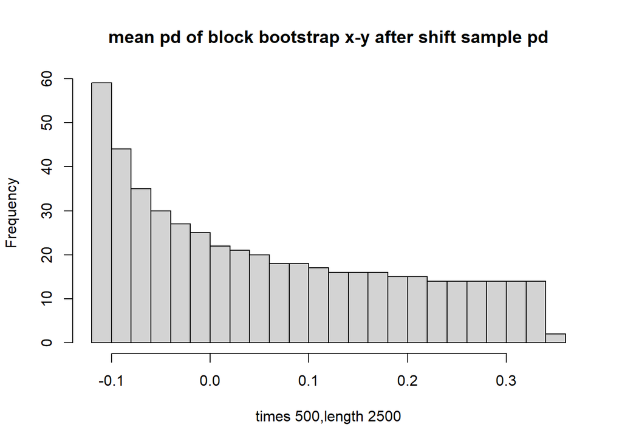

```r
#平移修正
tsdf_rec <- data.frame(x=tsdf$x,y=c(tsdf$y[4:length(tsdf$y)],tsdf$y[1:3]))
#分块重抽样100次
bootphase_df <- matrix(bphase(500,tsdf_rec$x,tsdf_rec$y),nrow=500)
hist(apply(bootphase_df,1,mean),breaks=30,main="mean pd of block bootstrap x-y after shift sample pd",xlab="times 500,length 2500")
```

### case2

**随机试验参数设置**

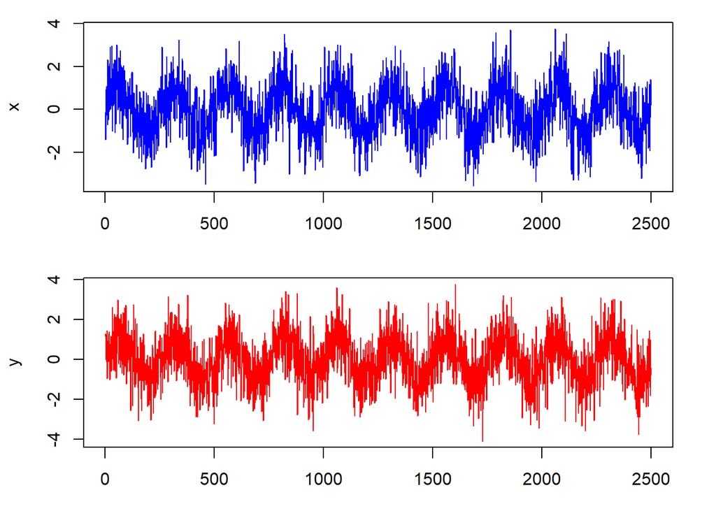

```r
tsdf_pd <- cons_ts_pairs(1,250,2500,-3)
par(mfrow = c(2,1),mar = c(3,4,1,2)+0.1)
plot(seq(1,dim(tsdf)[1]),tsdf_pd$x,type ="l",col="blue",xlab="",ylab="x")
plot(seq(1,dim(tsdf)[1]),tsdf_pd$y,type = "l",col="red",xlab="index",ylab="y")
```

### 2.1 原始相位差分布

```r
tempwc_pd <- analyze.coherency(tsdf_pd,my.pair=c(1,2),
                              loess.span = 0,
                              dt=1,dj=1/50,
                              lowerPeriod=64,
                              upperPeriod=1024,
                              make.pval = T,
                              n.sim=10)
```

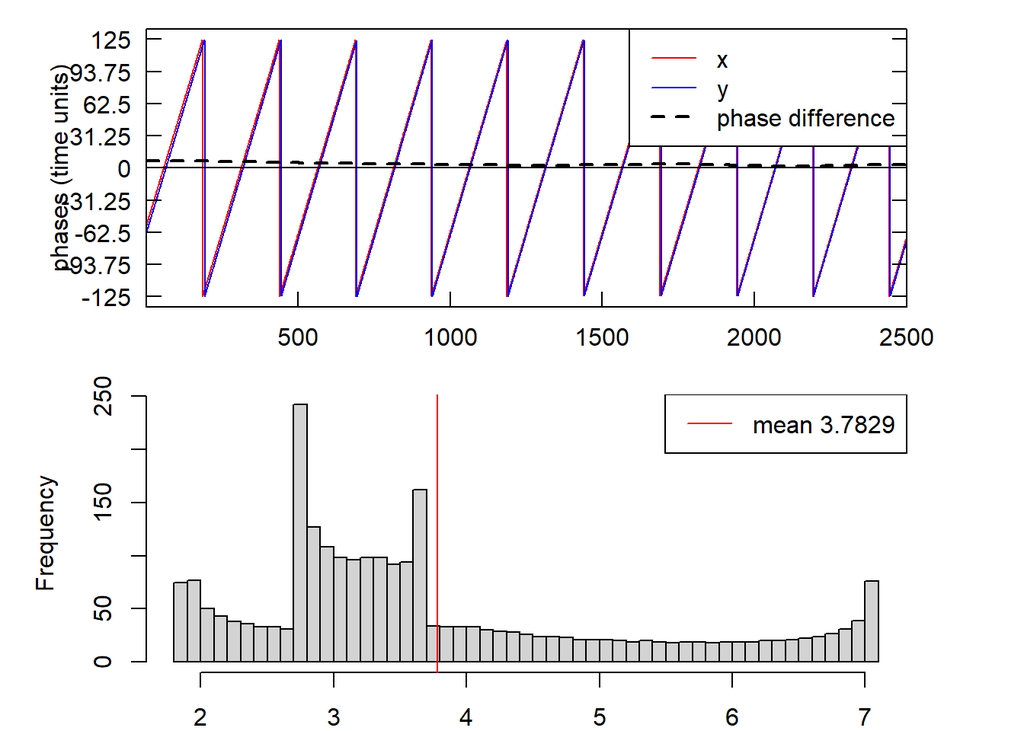

```r
#提取小波交叉谱计算相位角差值函数（相位差）
angle.series_pd <- tempwc_pd$Angle[which.min(abs(tempwc_pd$Period-250)),]#相位角差，范围在[-pi,pi]
phase_pd <- (angle.series_pd/pi)*(250/2)#相位差，范围在[-25,25]之间

#相位差图中坐标轴相位角到相位差的转换

par(mfrow=c(2,1))
par(mar=c(2, 5, 1, 4))
wc.sel.phases(tempwc_pd, sel.period = 250,
                only.sig = TRUE,
                which.sig = "wc",
                siglvl = 0.05,
                phaselim = c(-pi,+pi),
                phaselab = "phases (time units)",
                spec.phase.axis = list(at = at.ticks, labels = label.ticks),
                legend.coords = "topright", legend.horiz = FALSE,
                main = "", sub = "", timelab = "")
abline(h=0)
hist(phase_pd,breaks=50,main="",xlab="length 2500")
abline(v=mean(phase_pd),col="red")
legend("topright",paste("mean",round(mean(phase_pd),4)),col="red",lty=1)
```

### 2.2修正真实相位差，分块重抽样

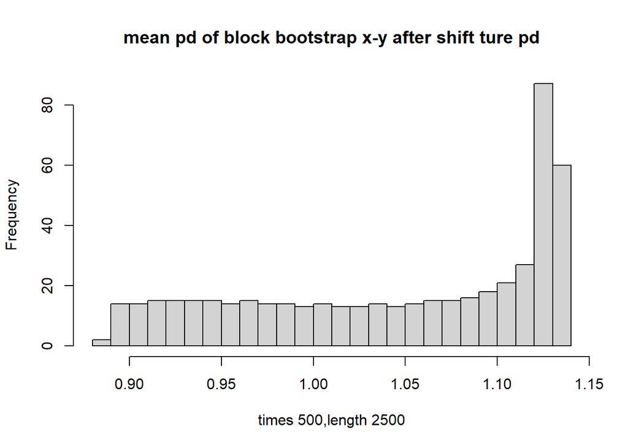

```r
#平移修正
tsdfpd_rec <- data.frame(x=tsdf_pd$x,y=c(tsdf_pd$y[4:length(tsdf_pd$y)],tsdf$y[1:3]))
bootphasepd_df <- matrix(bphase(500,tsdfpd_rec$x,tsdfpd_rec$y),nrow=500)
hist(apply(bootphasepd_df,1,mean),breaks=30,main="mean pd of block bootstrap x-y after shift ture pd",xlab="times 500,length 2500")
```

### 2.3修正样本方差，分块重抽样

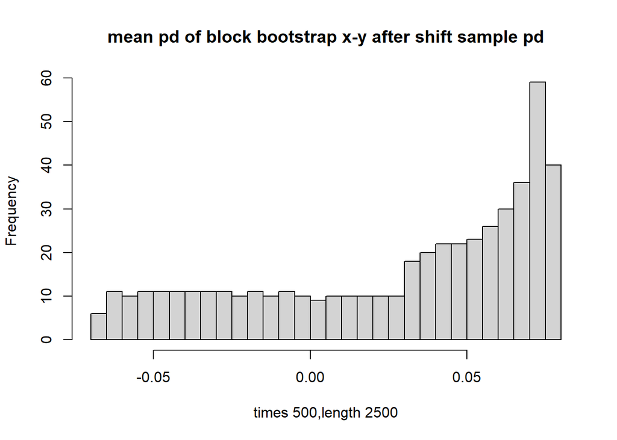

```r
#平移修正
tsdfpd_rec2 <- data.frame(x=tsdf_pd$x,y=c(tsdf_pd$y[5:length(tsdf_pd$y)],tsdf$y[1:4]))
bootphasepd_df2 <- matrix(bphase(500,tsdfpd_rec2$x,tsdfpd_rec2$y),nrow=500)
hist(apply(bootphasepd_df2,1,mean),breaks=30,main="mean pd of block bootstrap x-y after shift sample pd",xlab="times 500,length 2500")
```

### 3.补充

真实相位差为0时，不断抽取500对x-y测试相位差均值情况，用改样本试图刻画总体分布

```r
rmphase <- function(times,cons_ts_pairs,period,length,phasedif){
  #传入参数:循环次数,构造时序的函数,批量生成的时序周期，时序长度，时序相位差
  cl <- makeCluster(detectCores())#设置并行环境
  registerDoParallel(cl)#设置为使用所有可用处理器核心
  #创建任务
  result <- foreach(i = 1:times,.combine='c') %dopar% {
    library(WaveletComp)
    temp_ts <- cons_ts_pairs(1,period,length,phasedif = phasedif)
    tempwc <- analyze.coherency(temp_ts,my.pair = c("x","y"),
                            loess.span = 0,
                            dt=1,dj=1/50,
                            lowerPeriod = 24,
                            upperPeriod = 1024,
                            make.pval = T,
                            n.sim=10)
    #计算两时序在周期为50附近的小波相位角差值
    temp_angle <- tempwc$Angle[which.min(abs(tempwc$Period-period)),]
    #将相位角值转换成相位差值
    temp_phase <- (temp_angle/pi)*(period/2)
    mean(temp_phase)
  }
  stopCluster(cl)#关闭进程
  return(result)
}
```

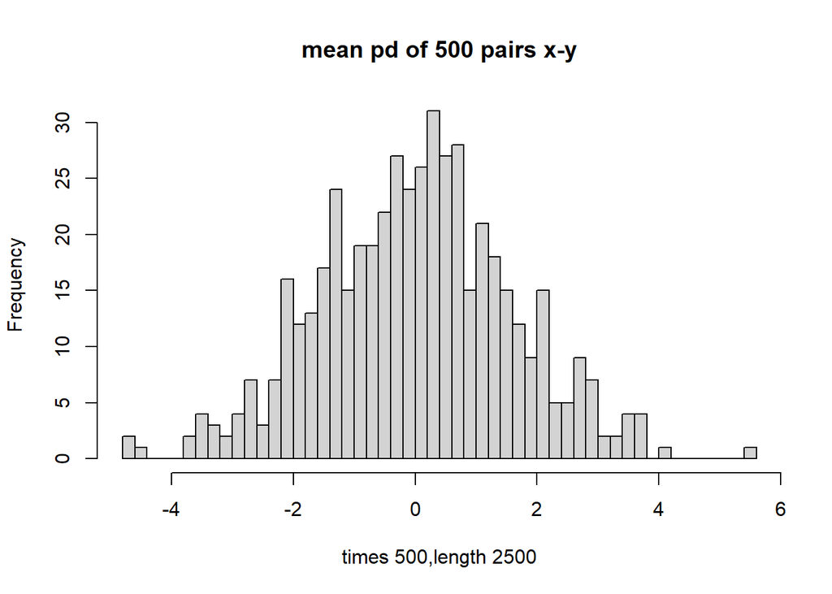

```r
rphase <- rmphase(500,cons_ts_pairs = cons_ts_pairs,250,2500,0)
hist(rphase,breaks=40,main="mean pd of 500 pairs x-y",xlab="times 500,length 2500")
```

在真实相位差为0的时候，x-y时序对的相位差均值分布大致呈正态分布，极端情况较少

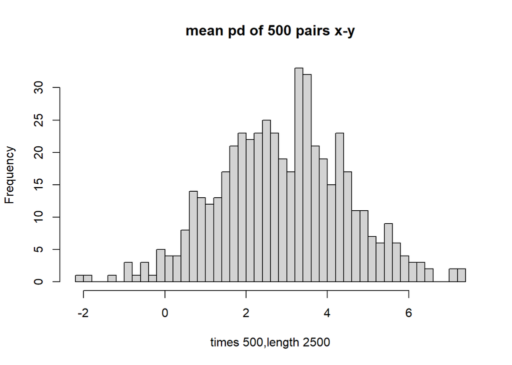

```r
rphase_pd <- rmphase(500,cons_ts_pairs = cons_ts_pairs,250,2500,-3)
hist(rphase_pd,breaks=40,main="mean pd of 500 pairs x-y",xlab="times 500,length 2500")
```

在真实相位差为3的时候，x-y时序对的相位差均值分布